# IE 360 HW1

## Introduction

In this assignment, I try to find an answer to "Are Mortagaged Sales statistics related to mortgage interest rates,exchange rate (USD/TL),and Consumer Price Index?". To avoid complex analysis, I am planning to find only correlation between those time series. The data which I used is provided by CBRT and from March 2017 to March 2020. Also, the frequency of data is monthly.

I only used xts package.

```r
#install.packages(xts)
library(xts)
```

There are 2 alternatives given here to create a xts object from a csv file. I preferred the second one.

```r
#rawdata <-"https://raw.githubusercontent.com/BU-IE-360/spring20-msahincakir/master/files/hw1/rawdata.csv"
#data_zoo<-read.zoo(rawdata, index.column=0, sep=";",quote = "",format = "%Y-%m-%d")
```

```r
dat<-read.csv('https://raw.githubusercontent.com/BU-IE-360/spring20-msahincakir/master/files/hw1/rawdata.csv',sep=";")
evbs<-xts(dat, order.by = as.Date(rownames(dat), '%Y-%m-%d'))
evbs
```

```
           Mortgaged_Sales USD_TL Mortgage_Interest    CPI
2017-03-01           50424   3.67             11.06 305.24
2017-04-01           43334   3.65             11.28 309.23
2017-05-01           41738   3.56             11.55 310.61
2017-06-01           35210   3.52             11.72 309.78
2017-07-01           38575   3.56             12.02 310.24
2017-08-01           38743   3.51             12.49 311.85
2017-09-01           40534   3.47             12.87 313.88
2017-10-01           38593   3.66             13.05 320.40
2017-11-01           37250   3.88             13.12 325.18
2017-12-01           34029   3.85             13.52 327.41
2018-01-01           28678   3.77             14.14 330.75
2018-02-01           27916   3.78             14.68 333.17
2018-03-01           32786   3.88             14.79 336.48
2018-04-01           27912   4.05             14.83 342.78
2018-05-01           36865   4.41             13.88 348.34
2018-06-01           47648   4.63             13.10 357.44
2018-07-01           30405   4.75             16.86 359.41
2018-08-01           12743   5.73             18.99 367.66
2018-09-01           11330   6.37             25.18 390.84
2018-10-01            8065   5.86             28.95 401.27
2018-11-01            5324   5.37             28.63 395.48
2018-12-01            7148   5.31             27.82 393.88
2019-01-01            6537   5.37             26.22 398.07
2019-02-01            8890   5.26             22.98 398.71
2019-03-01           22762   5.44             18.16 402.81
2019-04-01           22461   5.74             17.70 409.63
2019-05-01           14916   6.05             20.45 413.52
2019-06-01            7319   5.81             21.81 413.63
2019-07-01           13064   5.67             21.06 419.24
2019-08-01           34148   5.62             14.15 422.84
2019-09-01           57811   5.71             12.98 427.04
2019-10-01           50411   5.78             13.12 435.59
2019-11-01           43911   5.73             12.96 437.25
2019-12-01           50278   5.84             12.69 440.50
2020-01-01           42237   5.92             11.88 446.45
2020-02-01           43733   6.04             11.43 448.02
2020-03-01           43329   6.31             11.40 450.58
```

I calculated the correlation between Mortgaged sales and the other time series which are mortgage interest rates,exchange rate (USD/TL),and Consumer Price Index.

```r
corr<-cor(evbs[,1],evbs[,2:4])
corr
```

|  | USD_TL | Mortgage_Interest | CPI |
| --- | --- | --- | --- |
| Mortgaged_Sales | -0.3139563 | -0.9067689 | -0.1485551 |

As expected, mortgage interest rates is negatively correlated to mortgaged sales.

Then, I plotted each time series in different plots due to different scales of their data. However, the x axis is same, so it is easy follow the relations.

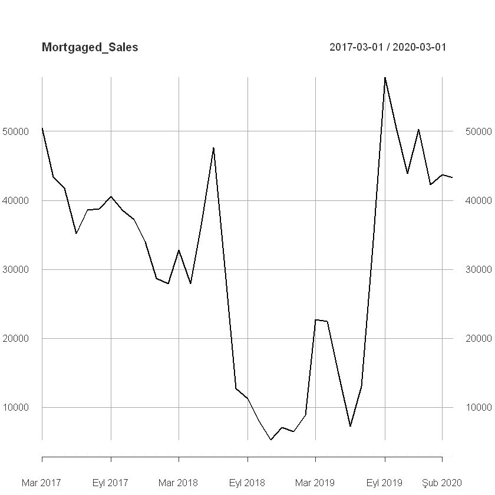

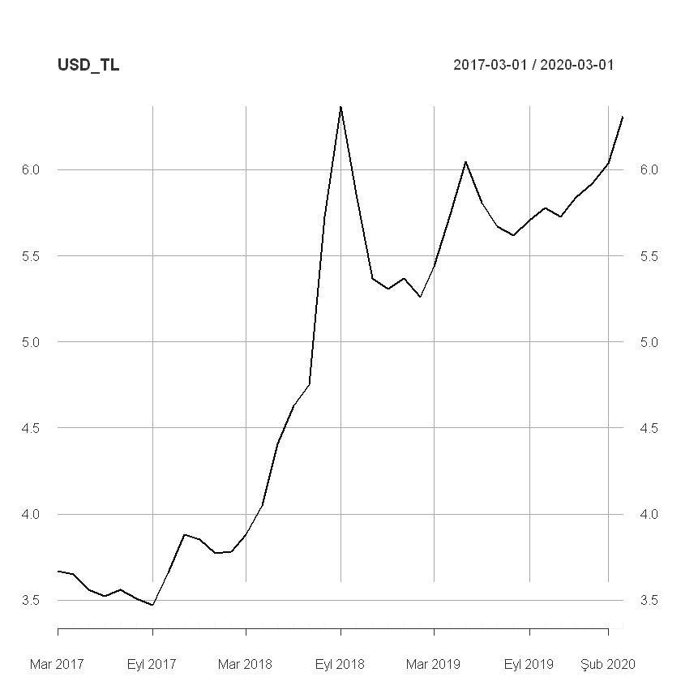

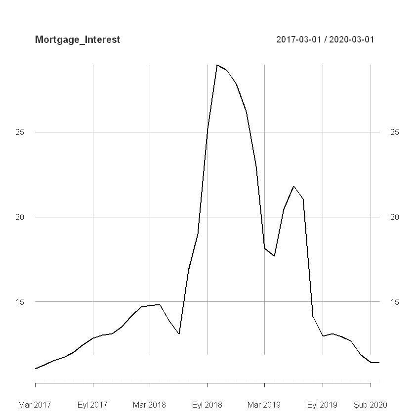

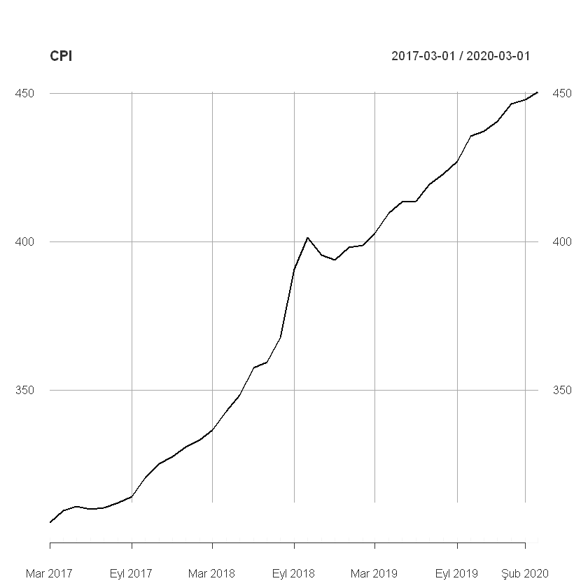

```r
par(mfrow=c(1, 1))
lapply(evbs,function(x){plot(x,main=colnames(x))})
```

## Conclusion

According to results, Mortgaged sales are strongly related with mortgage interest rates as expected. However, CPI and mortagage sales seem not really related wtih each other, which I have not expected. Also, the exchange rate does not have a considerable impact on mortagaged sales. During the assignment, I had an chance to experience xts package which makes things easier if one works with time series.

[Here](https://github.com/BU-IE-360/spring20-msahincakir/blob/master/files/hw1/ie360_hw1.ipynb) is the source code.